# Classifier_Calibration_Appendix

Peter

2022-12-03

# Online Appendix to Chapter 4: Application of Re-Calibration Techniques for Classifiers

## Assessing Calibration

Step 1: Classifier Training using Training Data

```r
target = "Target"
features <- names(train_df)
features <- features[! features %in% c(target)]
formula = as.formula(paste(target, paste(features, collapse=" + "), sep=" ~ "))

rf_classifier = classifier_train_func(classifier_model = "RF")
gbm_classifier = classifier_train_func(classifier_model = "GBM")
nb_classifier = classifier_train_func(classifier_model = "NB")
lr_classifier = classifier_train_func(classifier_model = "LR")
```

Step 2: Train Calibrator using Calibration Data

```r
# Assessing calibration of unseen data: calibration data set
rf_scored = classifier_score_func(classifier_model = "RF")
gbm_scored = classifier_score_func(classifier_model = "GBM")
nb_scored = classifier_score_func(classifier_model = "NB")
lr_scored = classifier_score_func(classifier_model = "LR")
```

To get a feeling for the distribution of the predicted scores, histograms and the empirical cumulative distributions are plotted:

```r
scores_hist = as.data.frame(cbind(RF = rf_scored$scores, GBM = gbm_scored$scores,
                                  NB = nb_scored$scores, LR = lr_scored$scores)) %>%
  pivot_longer(cols = c("RF", "GBM", "NB", "LR")) %>%
  ggplot()+
  geom_histogram(aes(x = value, fill = as.factor(name))) +
  facet_grid(name~.)+
  xlab("Predicted Score")+
  ylab("Count")+
  scale_fill_manual(values=c('#9932CC', "#DC143C", "#006400", "#6495ED"))+
  theme(legend.position = "none")

ecd = ggplot()+
  stat_ecdf(aes(x = rf_scored$scores, color = "Random Forest"))+
  stat_ecdf(aes(x = gbm_scored$scores, color = "GBM"))+
  stat_ecdf(aes(x = nb_scored$scores, color = "Naive Bayes"))+
  stat_ecdf(aes(x = lr_scored$scores, color = "Logistic"))+
  xlab("Predicted Score")+
  ylab("Cumulative Density")+
  theme(legend.position = "bottom", text = element_text(size = 12))+
  scale_color_manual('Classifier', values=c('#9932CC', "#DC143C", "#006400", "#6495ED"))
```

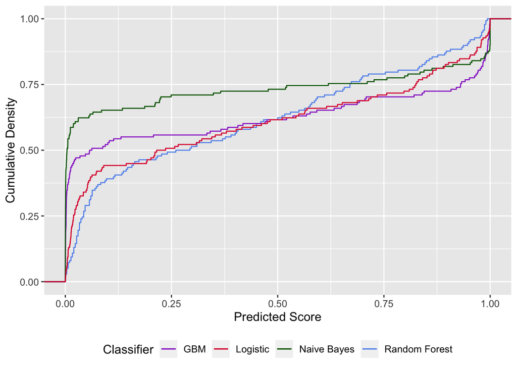

```r
ecd
```

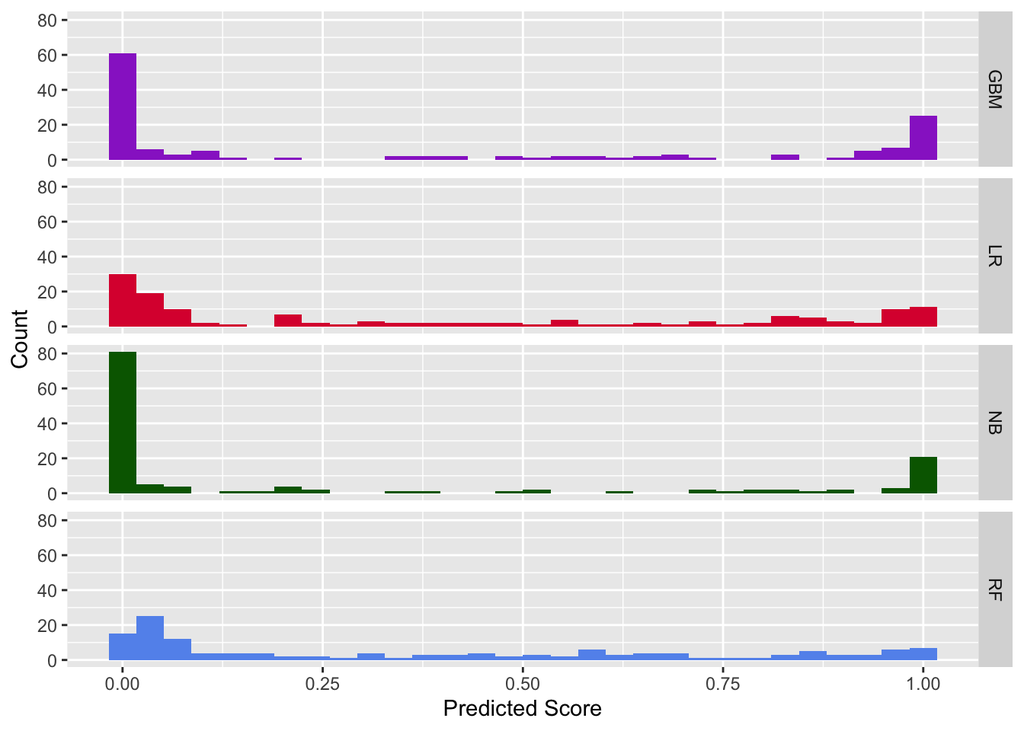

```r
scores_hist
```

### Calibration Assessment Methods

#### Binning and Counting

```r
rf_bc = bin_func(data = rf_scored, nbins = 10, eqdist = TRUE)
gbm_bc = bin_func(data = gbm_scored, nbins = 10, eqdist = TRUE)
nb_bc = bin_func(data = nb_scored, nbins = 10, eqdist = TRUE)
lr_bc = bin_func(data = lr_scored, nbins = 10, eqdist = TRUE)
```

```r
bc_plot = ggplot()+
  geom_point(aes(x = rf_bc$scores_mean, y = rf_bc$label_mean, color = "Random Forest"))+
  geom_line(aes(x = rf_bc$scores_mean, y = rf_bc$label_mean, color = "Random Forest"))+
  geom_point(aes(x = gbm_bc$scores_mean, y = gbm_bc$label_mean, color = "GBM"))+
  geom_line(aes(x = gbm_bc$scores_mean, y = gbm_bc$label_mean, color = "GBM"))+
  geom_point(aes(x = nb_bc$scores_mean, y = nb_bc$label_mean, color = "Naive Bayes"))+
  geom_line(aes(x = nb_bc$scores_mean, y = nb_bc$label_mean, color = "Naive Bayes"))+
  geom_point(aes(x = lr_bc$scores_mean, y = lr_bc$label_mean, color = "Logistic"))+
  geom_line(aes(x = lr_bc$scores_mean, y = lr_bc$label_mean, color = "Logistic"))+
  geom_abline(intercept = 0, slope = 1, linetype="dashed")+
  xlab("Mean Predicted Score")+
  ylab("Event Frequency")+
  theme(legend.position = "bottom", text = element_text(size = 12))+
  scale_color_manual('Classifier', values=c('#9932CC', "#DC143C", "#006400", "#6495ED"))
```

```r
bc_err = ggplot()+
  geom_point(aes(x = rf_bc$scores_mean, y = rf_bc$label_mean), color = "#6495ED", size = 2)+
  geom_line(aes(x = rf_bc$scores_mean, y = rf_bc$label_mean), color = "#6495ED", size = 1)+
  geom_errorbar(aes(x = rf_bc$scores_mean,
                    ymin = rf_bc$label_mean-rf_bc$label_sd,
                    ymax = rf_bc$label_mean+rf_bc$label_sd),
                color = '#a10028', size = 1)+
  geom_abline(intercept = 0, slope = 1, linetype="dashed")+
  xlab("Mean Predicted Score")+
  ylab("Event Frequency")+
  theme(legend.position = "bottom", text = element_text(size = 12))
```

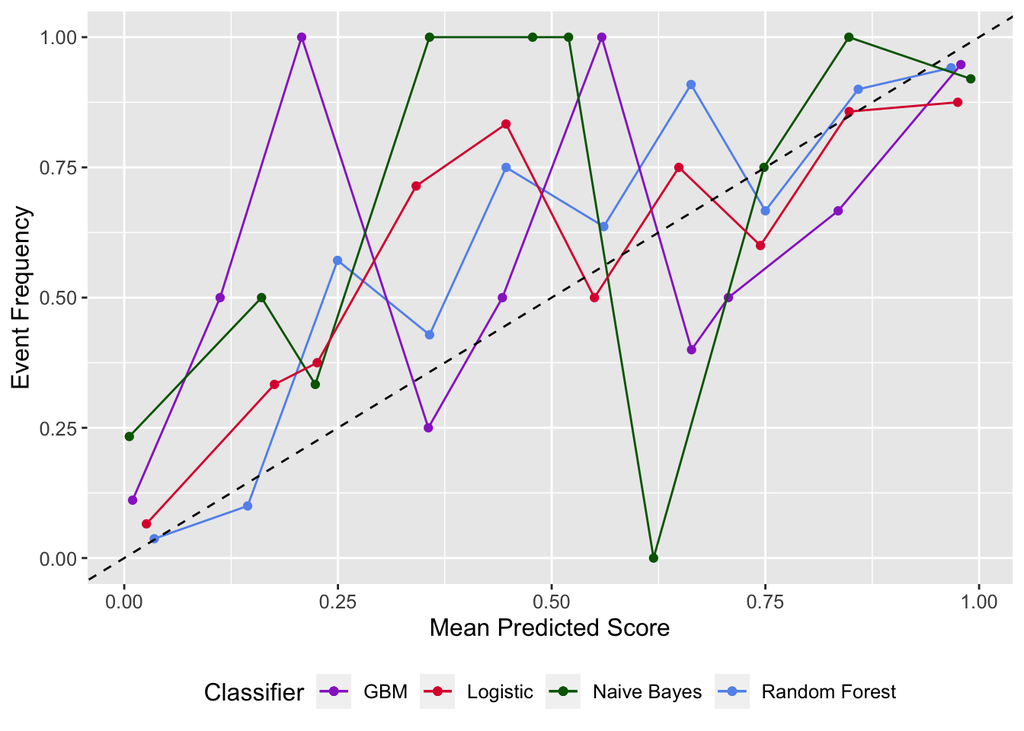

```r
bc_plot
```

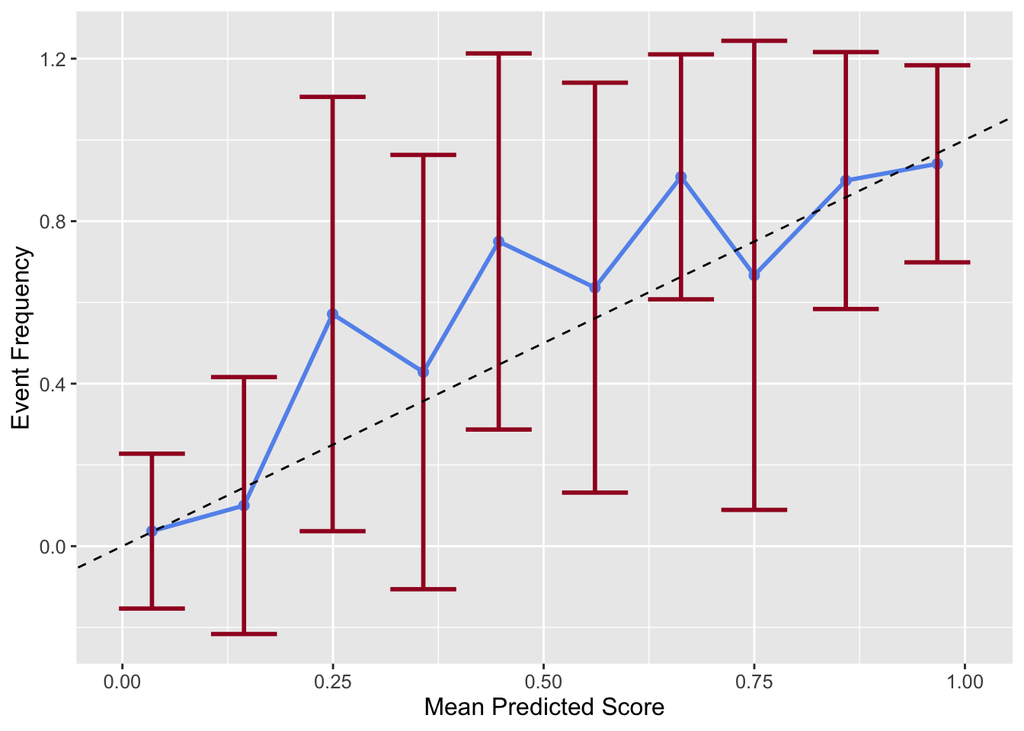

```r
bc_err
```

#### Sigmoid Scaling

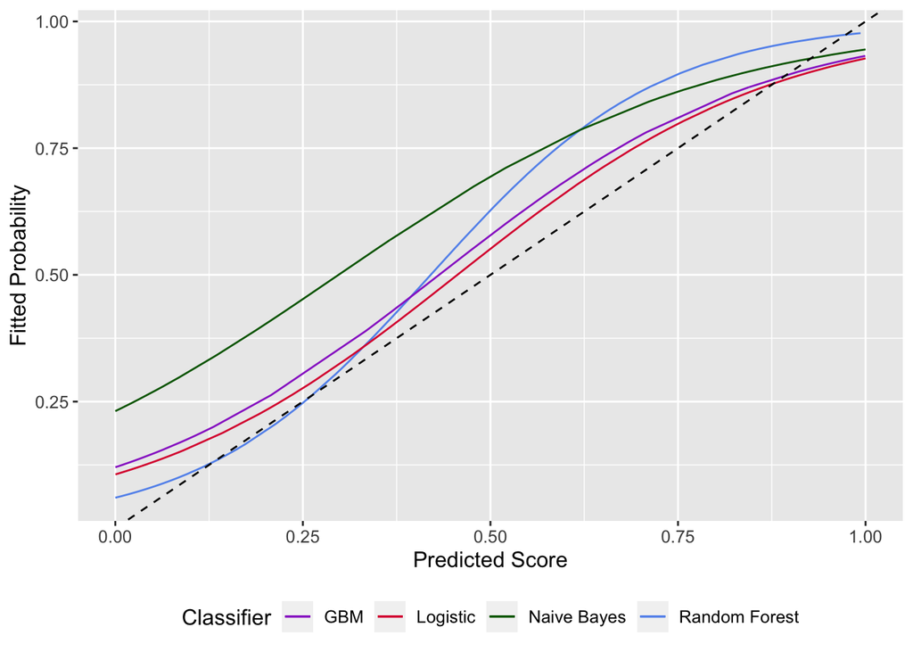

```r
rf_sig = sigmoid_fit_func(scores_uncal_label = rf_scored)
rf_sig_fit = rf_sig$preds_sigmoid
gbm_sig = sigmoid_fit_func(scores_uncal_label = gbm_scored)
gbm_sig_fit = gbm_sig$preds_sigmoid
nb_sig = sigmoid_fit_func(scores_uncal_label = nb_scored)
nb_sig_fit = nb_sig$preds_sigmoid
lr_sig = sigmoid_fit_func(scores_uncal_label = lr_scored)
lr_sig_fit = lr_sig$preds_sigmoid

sig_plot = ggplot()+
  geom_line(aes(x = rf_sig_fit$scores, y = rf_sig_fit$probs, color = "Random Forest"))+
  geom_line(aes(x = gbm_sig_fit$scores, y = gbm_sig_fit$probs, color = "GBM"))+
  geom_line(aes(x = nb_sig_fit$scores, y = nb_sig_fit$probs, color = "Naive Bayes"))+
  geom_line(aes(x = lr_sig_fit$scores, y = lr_sig_fit$probs, color = "Logistic"))+
  geom_abline(intercept = 0, slope = 1, linetype="dashed")+
  xlab("Predicted Score")+
  ylab("Fitted Probability")+
  theme(legend.position = "bottom", text = element_text(size = 12))+
  scale_color_manual('Classifier', values=c('#9932CC', "#DC143C", "#006400", "#6495ED"))
sig_plot
```

#### Isotonic Scaling

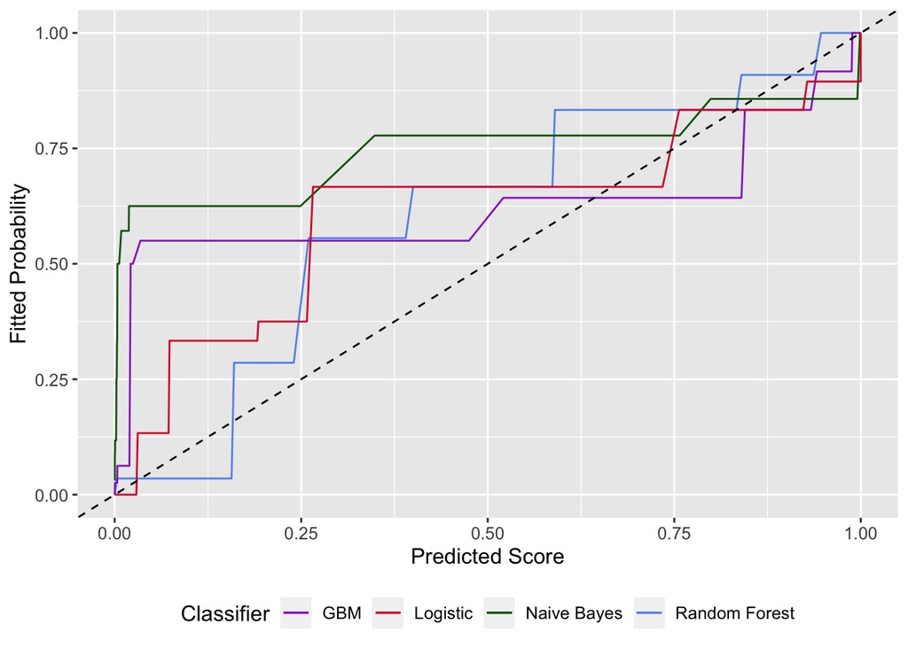

```r
rf_iso = isotonic_fit_func(scores_uncal_label = rf_scored)
rf_iso_fit = rf_iso$preds_iso
gbm_iso = isotonic_fit_func(scores_uncal_label = gbm_scored)
gbm_iso_fit = gbm_iso$preds_iso
nb_iso = isotonic_fit_func(scores_uncal_label = nb_scored)
nb_iso_fit = nb_iso$preds_iso
lr_iso = isotonic_fit_func(scores_uncal_label = lr_scored)
lr_iso_fit = lr_iso$preds_iso

iso_plot = ggplot()+
  geom_line(aes(x = rf_iso_fit$scores, y = rf_iso_fit$probs, color = "Random Forest"))+
  geom_line(aes(x = gbm_iso_fit$scores, y = gbm_iso_fit$probs, color = "GBM"))+
  geom_line(aes(x = nb_iso_fit$scores, y = nb_iso_fit$probs, color = "Naive Bayes"))+
  geom_line(aes(x = lr_iso_fit$scores, y = lr_iso_fit$probs, color = "Logistic"))+
  geom_abline(intercept = 0, slope = 1, linetype="dashed")+
  xlab("Predicted Score")+
  ylab("Fitted Probability")+
  theme(legend.position = "bottom", text = element_text(size = 12))+
  scale_color_manual('Classifier', values=c('#9932CC', "#DC143C", "#006400", "#6495ED"))
iso_plot
```

### Calibration Analysis

#### Score Decomposition

```r
rf_decomp = score_decomp_func(x = rf_iso_fit$scores, y_hat = rf_iso_fit$probs, y_obs = rf_iso_fit$label)
gbm_decomp = score_decomp_func(x = gbm_iso_fit$scores, y_hat = gbm_iso_fit$probs, y_obs = gbm_iso_fit$label)
nb_decomp = score_decomp_func(x = nb_iso_fit$scores, y_hat = nb_iso_fit$probs, y_obs = nb_iso_fit$label)
lr_decomp = score_decomp_func(x = lr_iso_fit$scores, y_hat = lr_iso_fit$probs, y_obs = lr_iso_fit$label)

decomp = data.frame(rbind(rf = rf_decomp[,c("S_x", "MCB", "DSC", "UNC")],
                          gbm = gbm_decomp[,c("S_x", "MCB", "DSC", "UNC")],
                          nb = nb_decomp[,c("S_x", "MCB", "DSC", "UNC")],
                          lr = lr_decomp[,c("S_x", "MCB", "DSC", "UNC")]))

knitr::kable(decomp, caption = "CORP Score Decomposition")
```

CORP Score Decomposition

|  | S_x | MCB | DSC | UNC |
| --- | --- | --- | --- | --- |
| rf | 0.1147515 | 0.0206232 | 0.1516184 | 0.2457467 |
| gbm | 0.1254152 | 0.0360953 | 0.1564268 | 0.2457467 |
| nb | 0.1965513 | 0.0821068 | 0.1313022 | 0.2457467 |
| lr | 0.1358465 | 0.0254759 | 0.1353761 | 0.2457467 |

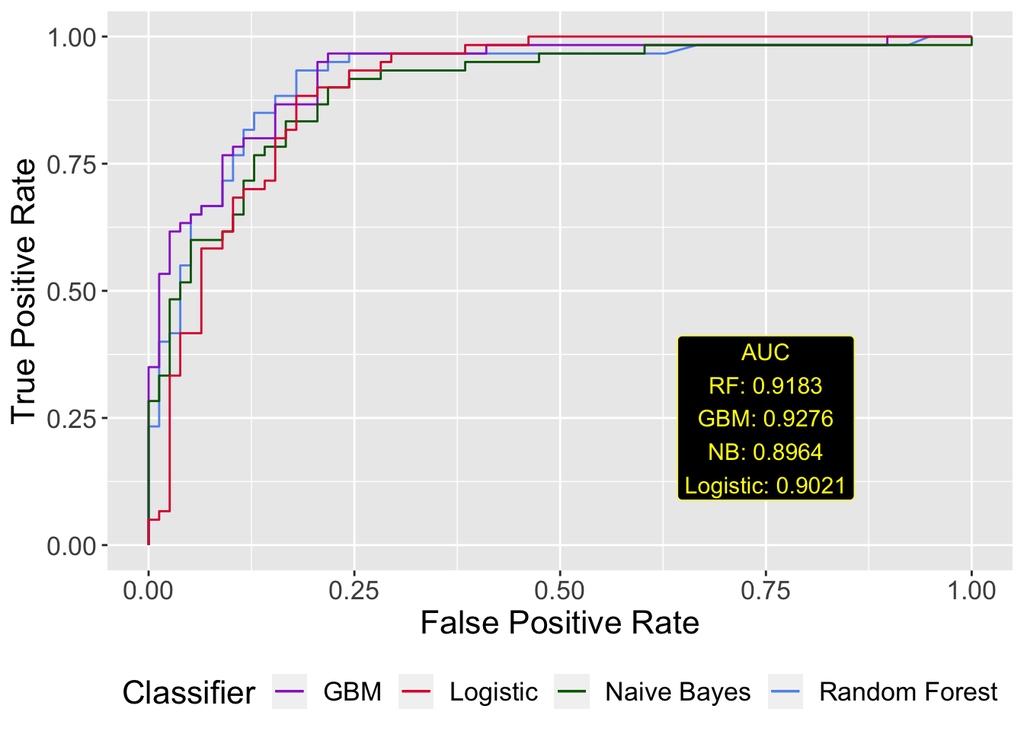

```r
rf_perf = calc_auc(scores = rf_scored$scores, label = rf_scored$label)
rf_auc = rf_perf$auc
rf_roc = rf_perf$roc
gbm_perf = calc_auc(scores = gbm_scored$scores, label = gbm_scored$label)
gbm_auc = gbm_perf$auc
gbm_roc = gbm_perf$roc
nb_perf = calc_auc(scores = nb_scored$scores, label = nb_scored$label)
nb_auc = nb_perf$auc
nb_roc = nb_perf$roc
lr_perf = calc_auc(scores = lr_scored$scores, label = lr_scored$label)
lr_auc = lr_perf$auc
lr_roc = lr_perf$roc

ggplot()+
  geom_line(aes(x = rf_roc@x.values[[1]], rf_roc@y.values[[1]], color = "Random Forest"))+
  geom_line(aes(x = gbm_roc@x.values[[1]], gbm_roc@y.values[[1]], color = "GBM"))+
  geom_line(aes(x = nb_roc@x.values[[1]], nb_roc@y.values[[1]], color = "Naive Bayes"))+
  geom_line(aes(x = lr_roc@x.values[[1]], lr_roc@y.values[[1]], color = "Logistic"))+
  theme(legend.position = "bottom", text = element_text(size = 16))+
  scale_color_manual('Classifier', values=c('#9932CC', "#DC143C", "#006400", "#6495ED"))+
  xlab("False Positive Rate")+
  ylab("True Positive Rate")+
  #scale_x_continuous(limits = c(0, 0.25))+
  #scale_y_continuous(limits = c(0.5, 1))+
  geom_label(aes(label = paste0("AUC", "\n", "RF: ", round(rf_auc, 4), "\n", "GBM: ", round(gbm_auc, 4), "\n",
                                "NB: ", round(nb_auc, 4), "\n", "Logistic: ", round(lr_auc, 4))),
             x = 0.75, y = 0.25, color = "yellow", fill = "black", size = 4)
```

#### Uncertainty Assessment

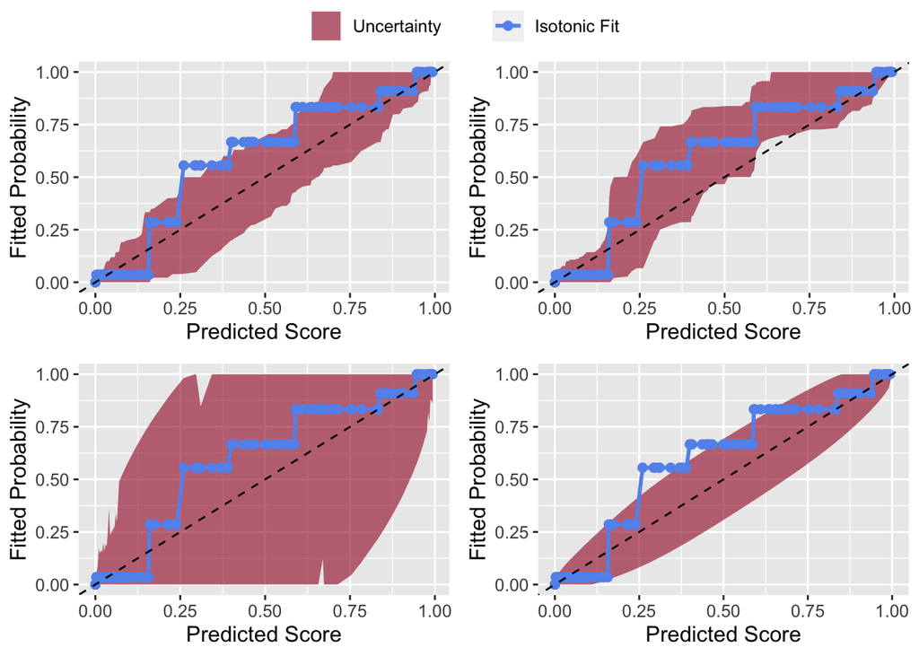

```r
reldiag_func = function(data, position, method, fit_col){
  library(reliabilitydiag)
  r = reliabilitydiag(x = data$scores, y = data$label, region.position = position, region.method = method)$x

  r_plot = ggplot()+
    geom_ribbon(aes(x=r$regions$x, ymin=r$regions$lower,
                    ymax=r$regions$upper,
                    fill = 'Uncertainty'), alpha = 0.6)+
    geom_point(aes(x=sort(data$scores), y=r$cases$CEP_pav, color='Isotonic Fit'), size = 2)+
    geom_line(aes(x=sort(data$scores), y=r$cases$CEP_pav, color='Isotonic Fit'), size = 1)+
    geom_abline(intercept = 0, slope = 1, linetype="dashed")+
    scale_color_manual('', values=c(fit_col))+
    scale_fill_manual('', values=c('#a10028'))+
    theme(legend.position = "none", text = element_text(size = 12))+
    xlab("Predicted Score")+
    ylab("Fitted Probability")

  return(r_plot)
}
ggarrange(reldiag_func(data = rf_scored, position = "diagonal", method = "resampling", fit_col = "#6495ED"),
          reldiag_func(data = rf_scored, position = "estimate", method = "resampling", fit_col = "#6495ED"),
          reldiag_func(data = rf_scored, position = "diagonal", method = "discrete_asymptotics", fit_col = "#6495ED"),
          reldiag_func(data = rf_scored, position = "diagonal", method = "continuous_asymptotics", fit_col = "#6495ED"),
          nrow = 2, ncol = 2, common.legend = TRUE)
```

## Re-Calibration

### Train-Calibration-Test Split

```r
rf_test = score_test_func(classifier_model = "RF", classifier = rf_classifier,
                          calibrator_sigmoid = rf_sig$calibrator_sigmoid,
                          iso_func_in = rf_iso$iso_func, test_df = test_df)
gbm_test = score_test_func(classifier_model = "GBM", classifier = gbm_classifier,
                           calibrator_sigmoid = gbm_sig$calibrator_sigmoid,
                           iso_func = gbm_iso$iso_func, test_df = test_df)
nb_test = score_test_func(classifier_model = "NB", classifier = nb_classifier,
                          calibrator_sigmoid = nb_sig$calibrator_sigmoid,
                          iso_func = nb_iso$iso_func, test_df = test_df)


test_assess_func(data = rf_test)
```

```
##          mean_score miscalibration discrimination uncertainty
## uncal    0.10808728    0.023508439      0.1649486   0.2495274
## sigmoid  0.10499608    0.020417236      0.1649486   0.2495274
## isotonic 0.09667475    0.003357524      0.1562102   0.2495274
```

```r
test_assess_func(data = gbm_test)
```

```
##          mean_score miscalibration discrimination uncertainty
## uncal     0.1291826     0.02711835      0.1474632   0.2495274
## sigmoid   0.1243174     0.02225325      0.1474632   0.2495274
## isotonic  0.1223025     0.01494889      0.1421738   0.2495274
```

```r
test_assess_func(data = nb_test)
```

```
##          mean_score miscalibration discrimination uncertainty
## uncal     0.2113858     0.09462265      0.1327642   0.2495274
## sigmoid   0.1635735     0.04681034      0.1327642   0.2495274
## isotonic  0.1337986     0.01395984      0.1296886   0.2495274
```

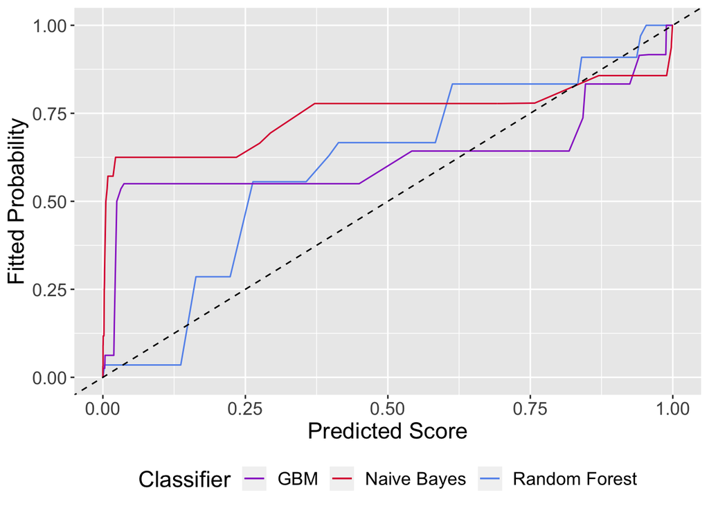

```r
ggplot()+
  geom_line(aes(x = rf_test$scores_uncal, y = rf_test$probs_iso, color = "Random Forest"))+
  geom_line(aes(x = gbm_test$scores_uncal, y = gbm_test$probs_iso, color = "GBM"))+
  geom_line(aes(x = nb_test$scores_uncal, y = nb_test$probs_iso, color = "Naive Bayes"))+
  geom_abline(intercept = 0, slope = 1, linetype="dashed")+
  xlab("Predicted Score")+
  ylab("Fitted Probability")+
  theme(legend.position = "bottom", text = element_text(size = 16))+
  scale_color_manual('Classifier', values=c('#9932CC', "#DC143C", "#6495ED"))
```

### Cross-Validation

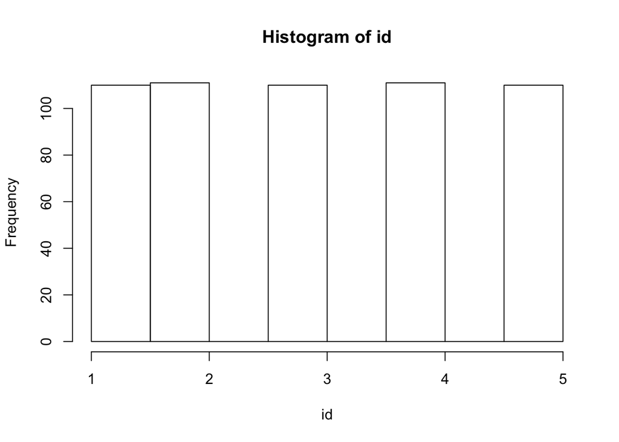

```r
train_df_cv = rbind(train_df, calib_df)
test_df_cv = test_df
set.seed(231122)
id = sample(rep(1:5, each = ceiling(nrow(train_df_cv)/5)))
id = id[1:nrow(train_df_cv)]
hist(id)
```

```r
train_cv = cbind(train_df_cv, id)

target = "Target"
features <- names(train_df_cv)
features <- features[! features %in% c(target)]
formula = as.formula(paste(target, paste(features, collapse=" + "), sep=" ~ "))


# Train Classification Models and Sigmoid/Isotonic Calibrator
rf_cv_train = train_cv_func(classifier_model = "RF", train_cv = train_cv)
gbm_cv_train = train_cv_func(classifier_model = "GBM", train_cv = train_cv)
nb_cv_train = train_cv_func(classifier_model = "NB", train_cv = train_cv)

# Run unseen test data through models

rf_test_cv_result = test_cv_func(classifier_model = "RF", Classifier_list = rf_cv_train$Classifier_list,
                              Sigmoid_list = rf_cv_train$Sigmoid_list, Isotonic_list = rf_cv_train$Isotonic_list,
                              test_df = test_df_cv)
gbm_test_cv_result = test_cv_func(classifier_model = "GBM", Classifier_list = gbm_cv_train$Classifier_list,
                                 Sigmoid_list = gbm_cv_train$Sigmoid_list, Isotonic_list = gbm_cv_train$Isotonic_list,  test_df = test_df_cv)
nb_test_cv_result = test_cv_func(classifier_model = "NB", Classifier_list = nb_cv_train$Classifier_list,
                                 Sigmoid_list = nb_cv_train$Sigmoid_list, Isotonic_list = nb_cv_train$Isotonic_list, test_df = test_df_cv)
```

```r
test_assess_func(data = rf_test_cv_result)
```

```
##          mean_score miscalibration discrimination uncertainty
## uncal     0.1032055     0.01837413      0.1646961   0.2495274
## sigmoid   0.1012311     0.01639980      0.1646961   0.2495274
## isotonic  0.1005435     0.01508271      0.1640666   0.2495274
```

```r
test_assess_func(data = gbm_test_cv_result)
```

```
##          mean_score miscalibration discrimination uncertainty
## uncal     0.1047334     0.01784319      0.1626372   0.2495274
## sigmoid   0.1075200     0.02062981      0.1626372   0.2495274
## isotonic  0.1125024     0.02321094      0.1602359   0.2495274
```

```r
test_assess_func(data = nb_test_cv_result)
```

```
##          mean_score miscalibration discrimination uncertainty
## uncal     0.1851119     0.06002553      0.1244411   0.2495274
## sigmoid   0.1553751     0.03028874      0.1244411   0.2495274
## isotonic  0.1440049     0.01414342      0.1196660   0.2495274
```

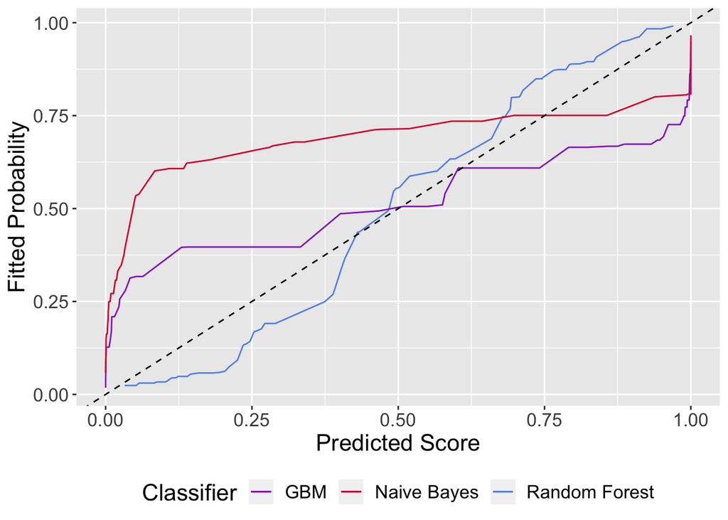

```r
# Graphical analysis
ggplot()+
  geom_line(aes(x = rf_test_cv_result$scores_uncal, y = rf_test_cv_result$probs_iso, color = "Random Forest"))+
  geom_line(aes(x = gbm_test_cv_result$scores_uncal, y = gbm_test_cv_result$probs_iso, color = "GBM"))+
  geom_line(aes(x = nb_test_cv_result$scores_uncal, y = nb_test_cv_result$probs_iso, color = "Naive Bayes"))+
  geom_abline(intercept = 0, slope = 1, linetype="dashed")+
  xlab("Predicted Score")+
  ylab("Fitted Probability")+
  theme(legend.position = "bottom", text = element_text(size = 16))+
  scale_color_manual('Classifier', values=c('#9932CC', "#DC143C", "#6495ED"))
```

### Comparison

This section compares the performance of the re-scaling process when confromting the trained models with unseen test data. These testing observation are scored using the trained classification models and then saled using the trained calibrators. The resulting scores/probabilities are then assessed in terms of their calibration. Therefore, the known true labels in the test data set are used. The analysis is conducted for the Random Forest classification model but could be applied to the other models as well.

Using the simple three-fold split to train the classifier, the calibrator and evaluate its combined performance, yields only a few distinct probability estimates when employing isotonic scaling on a small data set. With Cross-Validation, there are more unique probability estimates due to the averaging of the $k$ different calibration models. This characteristic is visible in the plot below. When mapping the predicted scores from the first stage classification model, to their respective calibrated counterpart, a wide range of distinct scores are assigned a unique calibrated probability. However, the cross-validated calibrated probabilities exhibit less horizontal segments, indicating more unique probability estimates for the test set observations.

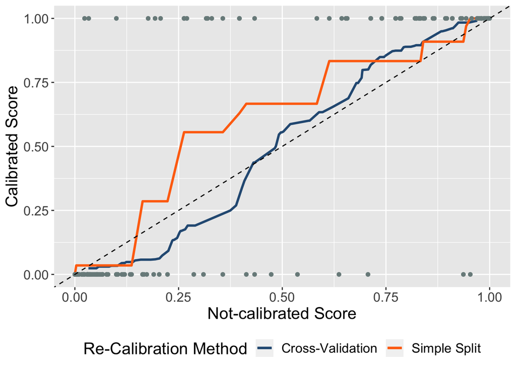

```r
ggplot()+
  geom_line(aes(x = rf_test_cv_result$scores_uncal, y = rf_test_cv_result$probs_iso, color = "Cross-Validation"), size=1.1)+
  geom_line(aes(x = rf_test$scores_uncal, y = rf_test$probs_iso, color = "Simple Split"), size=1.1)+
  geom_point(aes(x = rf_test$scores_uncal, y = rf_test$label), color = "#7a8b8b")+
  geom_abline(intercept = 0, slope = 1, linetype="dashed")+
  xlab("Not-calibrated Score")+
  ylab("Calibrated Score")+
  theme(legend.position = "bottom", text = element_text(size = 16))+
  scale_color_manual('Re-Calibration Method', values=c("#2a5a83", "#ff700f"))
```

Using the CORP procedure to analyse the calibration performance of the productive probability estimates, we see an improvement of the miscalibration when employing a re-scaling procedure. This holds for both approaches, simple and cross-validation. In this case, with a small data set, the simple split approach outperforms the cross-validation. Splitting the data in multiple even smaller subsets decreases the performance of the calibration model. Even though, their results are averaged, the simple split profits from having more data at hand to fit the calibrator.

In terms of discrimination, the cross-validation approach dominates. This can be identified from the Discrimination component in the CORP Score Decomposition but also from the AUC of the ROC curve. When using isotonic scaling, the number of distinct probability estimates decreases. CV produces more distinct estimates which allows for better discrimination. The scatter plot shows, that the simple split produces less distinct estimates as CV.

```r
# Score Decomposition
corp_simple = test_assess_func(data = rf_test)
corp_cv = test_assess_func(data = rf_test_cv_result)

corp_simple
```

```
##          mean_score miscalibration discrimination uncertainty
## uncal    0.10808728    0.023508439      0.1649486   0.2495274
## sigmoid  0.10499608    0.020417236      0.1649486   0.2495274
## isotonic 0.09667475    0.003357524      0.1562102   0.2495274
```

```r
corp_cv
```

```
##          mean_score miscalibration discrimination uncertainty
## uncal     0.1032055     0.01837413      0.1646961   0.2495274
## sigmoid   0.1012311     0.01639980      0.1646961   0.2495274
## isotonic  0.1005435     0.01508271      0.1640666   0.2495274
```

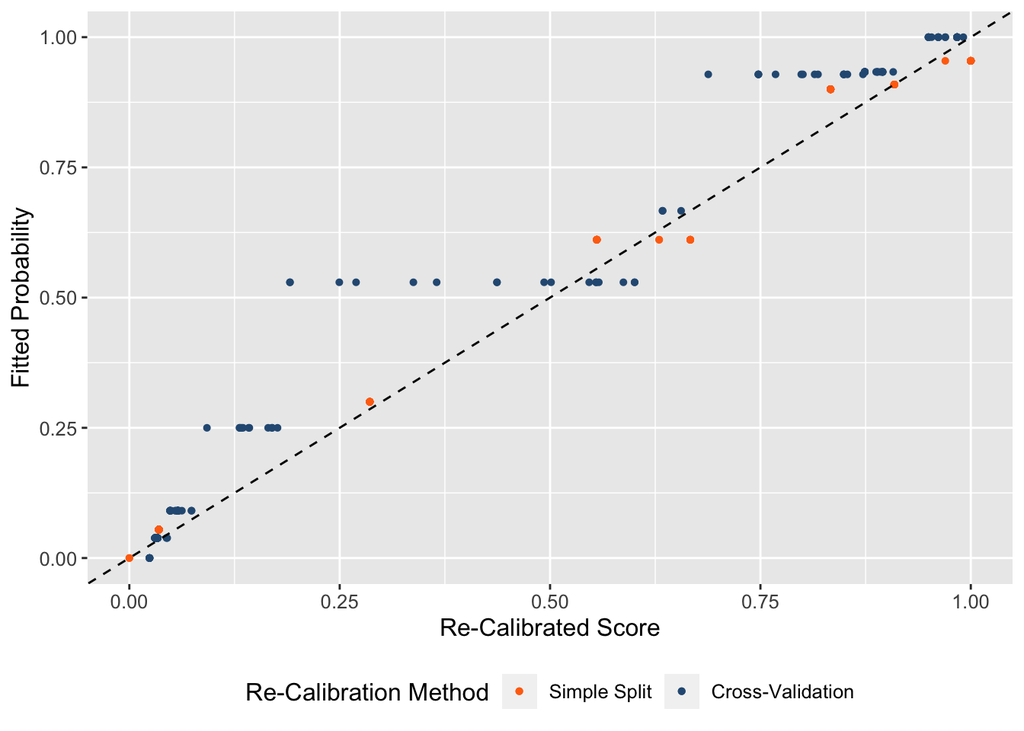

```r
# Obtain Calibration Assessment
r_simple  = reliabilitydiag(x = rf_test$probs_iso, y = rf_test$label)$x
r_cv = reliabilitydiag(x = rf_test_cv_result$probs_iso, y = rf_test_cv_result$label)$x

ggplot()+
    geom_point(aes(x=sort(rf_test$probs_iso), y=r_simple$cases$CEP_pav, color="Simple Split"), size = 1.1)+
    geom_point(aes(x=sort(rf_test_cv_result$probs_iso), y=r_cv$cases$CEP_pav, color="Cross-Validation"), size = 1.1)+
    geom_abline(intercept = 0, slope = 1, linetype="dashed")+
    scale_color_manual('Re-Calibration Method', values=c("#ff700f", "#2a5a83"),
                     breaks = c("Simple Split", "Cross-Validation"))+
    theme(legend.position = "bottom", text = element_text(size = 12))+
    xlab("Re-Calibrated Score")+
    ylab("Fitted Probability")
```

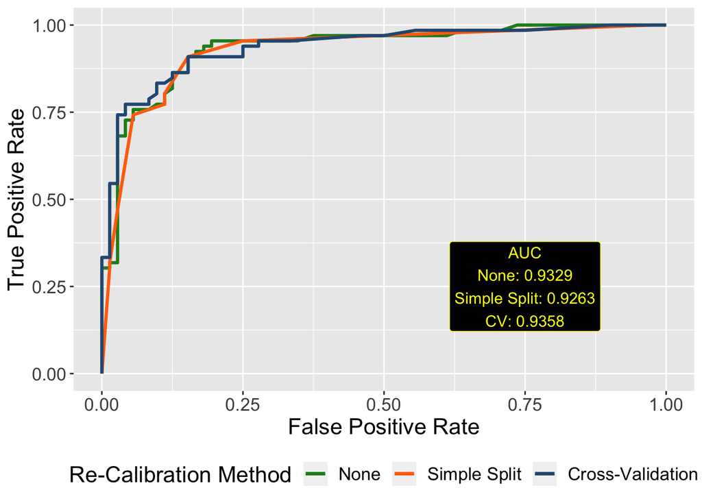

```r
# ROC comparison
perf_none = calc_auc(scores = rf_test$scores_uncal, label = rf_test$label)
perf_simple = calc_auc(scores = rf_test$probs_iso, label = rf_test$label)
perf_cv = calc_auc(scores = rf_test_cv_result$probs_iso, label = rf_test_cv_result$label)

ggplot()+
  geom_line(aes(x = perf_none$roc@x.values[[1]], perf_none$roc@y.values[[1]], color = "None"), size=1.1)+
  geom_line(aes(x = perf_simple$roc@x.values[[1]], perf_simple$roc@y.values[[1]], color = "Simple Split"), size=1.1)+
  geom_line(aes(x = perf_cv$roc@x.values[[1]], perf_cv$roc@y.values[[1]], color = "Cross-Validation"), size=1.1)+
  theme(legend.position = "bottom", text = element_text(size = 16))+
  scale_color_manual('Re-Calibration Method', values=c("#228B22", "#ff700f", "#2a5a83"),
                     breaks = c("None", "Simple Split", "Cross-Validation"))+
  xlab("False Positive Rate")+
  ylab("True Positive Rate")+
  geom_label(aes(label = paste0("AUC", "\n", "None: ", round(perf_none$auc, 4), "\n", "Simple Split: ", round(perf_simple$auc, 4), "\n",
                                "CV: ", round(perf_cv$auc, 4))),
             x = 0.75, y = 0.25, color = "yellow", fill = "black", size = 4)
```

## Optimization

Until now, the hyper-parameters of the classification models were treated as given. However, they can be optimized. Using the simple split approach, a search algorithm tries to identify the parameter combination that yields lowest miscalibration of re-calibrated scores of a testing data set. When calibration is not of interest, other metrics can used for optimization, as the AUC.

### Grid Search

Grid search uses a grid of pre-defined parameter values and tries to find the combination that yields an optimal metric value, i.e. a minimum miscalibration of an unseen test data set.

```r
MCB_GS = matrix(ncol = 4)
MCB_GS = array(dim = c(3,3,3))

mtry_GS = c(1, 3, 5)
ntree_GS = c(100, 200, 300)
maxnodes_GS = c(5, 10, 15)

for (i in c(1:3)) {
  for(j in c(1:3)){
    for (k in c(1:3)) {
      set.seed(1234)
      classifier_GS = randomForest::randomForest(formula, data = train_df,
                                                 mtry = mtry_GS[i],
                                                 ntree = ntree_GS[j],
                                                 maxnodes = maxnodes_GS[k],
                                                 nodesize = 3,
                                                 importance = FALSE)

      # Score Calibration data set on classifier
      scores_uncal_GS = predict(classifier_GS, newdata = calib_df, type = "prob")[,2]

      scores_uncal_label_GS = as.data.frame(cbind(scores = scores_uncal_GS,
                                                  label  = as.numeric(calib_df$Target)-1))


      # Train Isotonic regression: no hyper parameters needed
      rf_iso_GS = isotonic_fit_func(scores_uncal_label = scores_uncal_label_GS)
      rf_iso_fit_GS = rf_iso_GS$preds_iso
      iso_func_in_GS = rf_iso_GS$iso_func

      # Score Test Data on classifier
      scores_uncalib_test_GS = predict(classifier_GS, newdata = test_df, type = "prob")[,2]
      recalib_iso_test_GS = iso_func_in_GS(scores_uncalib_test_GS)

      calibs_test = as.data.frame(cbind(label = as.numeric(test_df$Target)-1,
                                        scores_uncal = scores_uncalib_test_GS,
                                        probs_iso = recalib_iso_test_GS))
      calibs_test = calibs_test[order(calibs_test$scores_uncal),]

      # Score Decomposition to obtain MCB
      r_GS = summary(reliabilitydiag(x = calibs_test$probs_iso, y = calibs_test$label))
      MCB_GS[i, j, k] = r_GS$miscalibration
    }
  }
}

idx_min_GS = which(MCB_GS == min(MCB_GS), arr.ind = TRUE)
as.data.frame(cbind(mtry = mtry_GS[idx_min_GS[1]],
                    ntrees = ntree_GS[idx_min_GS[2]],
                    maxnodes = maxnodes_GS[idx_min_GS[3]],
                    optimalMCB = MCB_GS[idx_min_GS]))
```

```
##   mtry ntrees maxnodes  optimalMCB
## 1    1    300       15 0.003391782
```

Grid search identifies a minimum miscalibration, when using mtry = 1, ntrees = 300 and maxnodes = 15. Since there are even more hyper-parameters to choose, the search can be extended. It is also useful to use a range of different values for each parameter but the computational demand increases quickly.

### Genetic Algorithm Optimization

The genetic algorithm learns iteration by iteration in which direction to change the parameter values to optimize the metric.

```r
library(gramEvol)
library(parallel)

eval_func = function(gen, train, calib, test, model_type, metric){
  # Train Classifier
  set.seed(1234)
  classifier_GA = randomForest::randomForest(formula, data = train,
                                          mtry = gen[1],
                                          ntree = gen[2],
                                          maxnodes = gen[3],
                                          nodesize = 3,
                                          importance = FALSE)

  # Score Calibration data set on classifier
  scores_uncal_GA = predict(classifier_GA, newdata = calib, type = "prob")[,2]

  scores_uncal_label_GA = as.data.frame(cbind(scores = scores_uncal_GA,
                                           label  = as.numeric(calib$Target)-1))

  # Train Isotonic regression: no hyper parameters needed
  rf_iso_GA = isotonic_fit_func(scores_uncal_label = scores_uncal_label_GA)
  rf_iso_fit_GA = rf_iso_GA$preds_iso
  iso_func_in_GA = rf_iso_GA$iso_func

  # Score Test Data on classifier
  scores_uncalib_test_GA = predict(classifier_GA, newdata = test, type = "prob")[,2]
  recalib_iso_test_GA = iso_func_in_GA(scores_uncalib_test_GA)

  calibs_test = as.data.frame(cbind(label = as.numeric(test$Target)-1,
                                    scores_uncal = scores_uncalib_test_GA,
                                    probs_iso = recalib_iso_test_GA))
  calibs_test = calibs_test[order(calibs_test$scores_uncal),]

  # Score Decomposition to obtain MCB
  r_GS = summary(reliabilitydiag(x = calibs_test$probs_iso, y = calibs_test$label))
  MCB = r_GS$miscalibration
  negDSC = -r_GS$discrimination
  if(metric == "MCB"){
    # Return MCB as objective to minimize
    return(MCB)
  }else if(metric == "DSC"){
    # Return negative DSC as objective to minimize, as DSC should be maximized
    return(negDSC)
  }


}

monitor_func = function(result){
  cat("Best of gen: ", min(result$best$cost), "Params: ", result$best$genome, "\n")
}
```

Optimizing on minimum Miscalibration

```r
system.time({
  set.seed(231122)
  gen_res_rf = GeneticAlg.int(genomeLen = 3, genomeMin = c(1, 50, 1), genomeMax = c(4, 500, 15),
                              popSize = 9, iterations = 5, mutationChance = 0.2, plapply = mclapply,
                              allowrepeat = TRUE, monitorFunc = monitor_func,
                              evalFunc = function(x) eval_func(x, train = train_df,
                                                               calib = calib_df,
                                                               test = test_df,
                                                               model_type = "RF",
                                                               metric = "MCB"))
})
```

```
## Best of gen:  0.0026323 Params:  2 354 10
## Best of gen:  0.003975002 Params:  1 136 2
## Best of gen:  0.005602458 Params:  2 397 8
## Best of gen:  0.004098251 Params:  1 315 11
## Best of gen:  0.004098251 Params:  1 315 11
```

```
##    user  system elapsed
##  21.127   2.476  14.453
```

Optimizing on maximum Discrimination

```r
system.time({
set.seed(231122)
gen_res_rf = GeneticAlg.int(genomeLen = 3, genomeMin = c(1, 50, 1), genomeMax = c(4, 500, 15),
                            popSize = 9, iterations = 5, mutationChance = 0.2, plapply = mclapply,
                            allowrepeat = TRUE, monitorFunc = monitor_func,
                            evalFunc = function(x) eval_func(x, train = train_df,
                                                             calib = calib_df,
                                                             test = test_df,
                                                             model_type = "RF",
                                                             metric = "DSC"))
})
```

```
## Best of gen:  -0.1636639 Params:  3 404 14
## Best of gen:  -0.1639898 Params:  4 404 14
## Best of gen:  -0.1640125 Params:  4 402 14
## Best of gen:  -0.1640125 Params:  4 402 14
## Best of gen:  -0.1640125 Params:  4 402 14
```

```
##    user  system elapsed
##  22.683   2.265  15.323
```